# UrbanClap Assignment

#### This is the solution to the Assignment 1 for the Business Analytics intern position in UrbanClap, Gurgaon

### The following queries have been solved in this assignmnent

1. ```
   Plot new users acquired every month on a bar chart (New user in a month = a customer who has placed a request for the first time ever)
   ```

2. ```
   30-Day repeat rate is defined as percentage of new users who have placed a 2nd order within 30 days of placing their first order.
   What is the 30-day repeat rate of users acquired in December 2017?
   ```

3. ```
   What is the 90-day repeat rate of users acquired in Jan,Feb,March 2018?
   ```

4. ```
   Use logistic regression to predict the 90-day repeat of users acquired in November 2018.
   ```

5. ```
   Plot the distribution of users by frequency of their 90-day repeat (Number of times user repeated within first 90 days)
   ```

### Solution 1 : Users acquired every month on a bar chart

| Year Of Booking | Month Of Booking | New Users |
| --- | --- | --- |
| 2017 | 12 | 2424 |
| 2018 | 1 | 1892 |
|  | 2 | 1549 |
|  | 3 | 1490 |
|  | 4 | 1346 |
|  | 5 | 1264 |
|  | 6 | 1273 |
|  | 7 | 1208 |
|  | 8 | 1120 |
|  | 9 | 1020 |
|  | 10 | 1110 |
|  | 11 | 1015 |

**3. Plotting / Visualising the data for `num_of_new_users` (Number of new users) w.r.t. month and year**

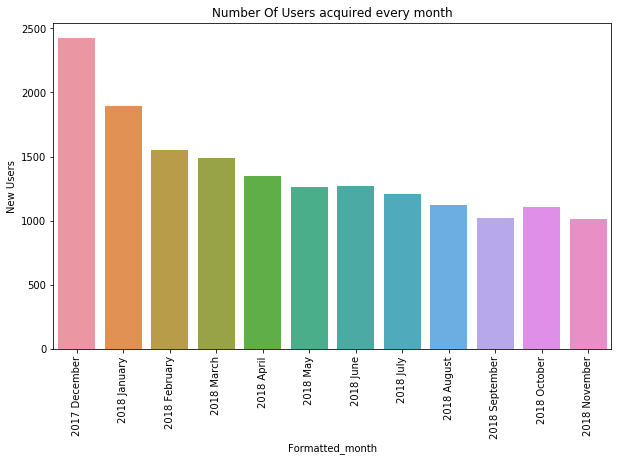

[interactive chart not shown]

> **Insights**
> - Number of new users in January 2018 dropped the most ie 28.118 %
> - Number of New Users in May had dropped almost about to 52.14% of sales in Deceember 2017  
>   **However**, the total users engaging on the service remained roughly the same as seen in the above graph

### **Solution 2 : What is the 30-day repeat rate of users acquired in December 2017?**

Solution :

```
30 Day Repeat Rate (for less than 30 days)  : 16.625412541254125
30 Day Repeat Rate (for less than equal to 30 days) : 16.831683168316832
```

### **Solution 3 : What is the 90-day repeat rate of users acquired in Jan, Feb, March 2018?**

Solution

```
30 Day Repeat Rate (for less than 90 days)  : 20.54350030419793
30 Day Repeat Rate (for less than equal to 90 days) : 20.74629892516731
```

### **Solution 4 : Predict the 90-day repeat of users acquired in November 2018 using Logistic Regression**

Solution

```
Predicted 90 day rate :25.254237288135593
```

### Solution 5 : Plot the distribution of users by frequency of their 90-day repeat

**2. Plotting Using Seaborn**

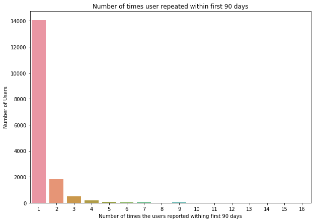

**3. Plotting Using Plotly for more interactivity**

[interactive chart not shown]

## Closing Note

> I would like to express my appreciation for considering me to be a part of the internship technical round.  
> I hope you like this small sampling of my work.  
> I **SINCERELY** want to work with a company as good as UrbanClap  
> I look forward to create many such documents and more with your team

> **Please** get in touch just in case if you think I missed anyhting at the below contact details
> - Phone - `+91-9871966592 (WhatsApp Active)`
> - EMail - `revantgupta2@gmail.com`
> - LinkedIN - `https://www.linkedin.com/in/revantg/`
> - Twitter - `https://twitter.com/revant_g`